# 吉利汽车发展史：从台州冰箱厂到全球收购家

更新日期：2026年5月31日

2026年5月31日

如果你站在 1997 年的浙江台州街头，问任何一个本地人：“这个叫李书福的家伙说要造汽车，你信不信？”——大概率回答会是一阵嘲笑。

那一年的李书福，是个从冰箱配件转做摩托车的农村企业家。他没有汽车工程师团队，没有牌照，没有合资伙伴，甚至连”汽车”这两个字怎么写到公司名上都不被国家发改委认可。他说过一句让整个汽车圈儿当成笑话的话——**“汽车不就是四个轮子加两个沙发吗？”**

不到三十年后，这家被嘲笑的小厂——

- 拥有**沃尔沃汽车** Volvo Cars 100%。
- 拥有**英国跑车品牌路特斯** Lotus 51%。
- 拥有**马来西亚国民车企宝腾** Proton 49.9%。
- 拥有**伦敦黑色出租车** LEVC 100%。
- 是**奔驰母公司**（Mercedes-Benz Group）**最大单一股东** 9.69%。
- 持有**沃尔沃集团**（Volvo AB，重卡）大量股份。
- 拥有自家的 **领克 Lynk & Co、极氪 Zeekr、银河 Galaxy、几何 Geometry、Smart（与奔驰合资）、Polestar（与沃尔沃合资）、Farizon 远程商用车、曹操出行**——加在一起 **十几个汽车品牌**。

2024 年，**吉利控股集团**全年卖出 **333.7 万辆**汽车——**全球前十大车企**之一。

[醒木]

更值得记住的是——**吉利没有比亚迪那种”自己做电池”的垂直一体化基因**，**没有奇瑞那种”22 年出口冠军”的渠道积累**，**没有上汽那种”国资大厂”的政策红利**。

它做了一件几乎所有中国民企都没敢做的事——**它在全球范围内”买”。它把别人不要的、卖不掉的、即将倒闭的国际汽车品牌——一个一个收购回来，盘活，整合，再放出去**。

这份教程把吉利四十年拆开来讲。理解它的特别之处不在于”也卖了很多车”，而在于它做出了一种少见的公司：**一家用”收购整合飞轮”代替”自研路径”的中国汽车集团**。

> **本教程会覆盖**：1986 李书福冰箱配件起家、1997 “四个轮子加沙发”造车梦、2001 民营车牌第一张、2007 宁波宣言、2010-03 18 亿美元收购沃尔沃、2013 收购伦敦出租、2017 路特斯 + 宝腾、2018 入股戴姆勒 9.69%、2019 Smart 合资、2021 极氪、2023 银河、2024 集团 333.7 万辆 / NEV 88 万辆、极氪欧洲扩张、Polestar 持续亏损、以及把”收购整合飞轮”抽象成可迁移启示。

## 第1章 为什么应该认识吉利

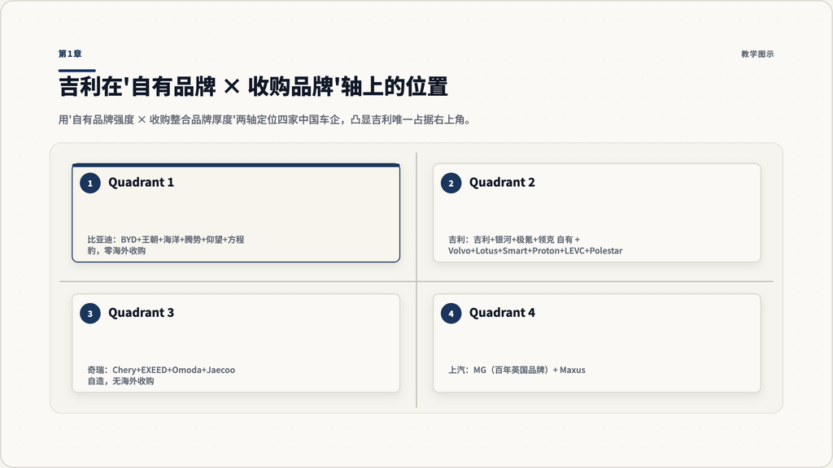

第1章：吉利在自有 vs 收购品牌轴上的位置

### 1.1 一个被简化叙述的公司

中国汽车产业里，吉利是被最严重**简化叙述**的一家。

大多数消费者对吉利的印象停留在这几个标签——

- **“收购沃尔沃的中国老板”**。
- **“做过烂车，现在做好了”**。
- **“中国版大众集团”**。

这三个标签都对，但**都太浅**。

真正的吉利是这么个东西：**一家以收购整合为方法论、用十几个品牌切割不同市场和心智的汽车集团**。它的能力中心不是制造、不是研发、不是渠道——**是”找到濒死的好品牌，盘活它，再用它”**。

### 1.2 一组数字看清楚位置

把 2024 年的关键数字放在一起：

- **吉利控股集团（Zhejiang Geely Holding Group）**：全年销 **333.7 万辆**，同比 +22%。
  - 这里头包括 Volvo Cars、Polestar、Lotus、Smart、Proton、LEVC、Farizon、Cao Cao 等。
- **吉利汽车（Geely Auto，香港上市 0175.HK）**：全年销 **217 万辆**，+32%；**新能源销 88 万辆，+92%**。
  - 这里头包括 Geely 主品牌 + 银河 + 极氪 + 领克的中国销量。
- **吉利主品牌**：167 万辆，+27%。
- **银河系列**：49.4 万辆，+80%。
- **极氪**：22.2 万辆，+87%。
- **领克**：28.5 万辆，+30%。

集团 2027 年目标：**500 万辆**。

[一组对照]

- **比亚迪 2024**：427 万辆，**100% 新能源**。
- **奇瑞 2024**：260 万辆，出口冠军。
- **吉利 2024（控股）**：333.7 万辆，**多品牌矩阵**。

三家公司各有 600+ 万辆量级的中国市场雄心，但**走的是三种完全不同的路**。

### 1.3 一张图理解吉利的位置

如果把主要中国车企画在”**自有品牌强 × 收购整合品牌强**”两个维度上：

- **比亚迪**：自有品牌极强（BYD + 王朝 + 海洋 + 腾势 + 仰望 + 方程豹），**几乎没有海外收购**。
- **奇瑞**：自有品牌中等（Chery + EXEED），**有 Omoda + Jaecoo 但都是自己造的**。
- **上汽**：自有品牌一般，但 **收购了 MG**（百年英国品牌）。
- **吉利**：自有品牌中等 + **十几个海外收购整合品牌（沃尔沃 / 路特斯 / 宝腾 / LEVC / Polestar / Smart / Proton…）**。

吉利在这张图上占据**右上角独有的位置**：**收购整合品牌资产最厚的中国车企**。

### 1.4 这一章你要带走的三件事

- 吉利不是”中国版大众”，是**用并购整合代替自研路径**的中国汽车集团。
- 集团 vs 上市公司是两个概念：**控股 333.7 万 / 上市 217 万**——别混着算。
- 接下来的章节会回答一个核心问题：**为什么吉利敢买这么多公司？买回来之后怎么不被消化不良拖垮？**

### 1.5 三问自检

不打开搜索，试着回答：

- 你能说出吉利集团旗下三个海外品牌吗？分别是干什么的？
- 沃尔沃和 Polestar 是什么关系？跟吉利又是什么关系？
- 极氪、银河、领克、几何——哪个是吉利自有？哪个是合资？哪个是收购？

如果三个里答不上来两个，说明你对吉利的认知**至少落后五年**。继续读。

## 第2章 浙江冰箱厂主的造车梦（1986-1997）

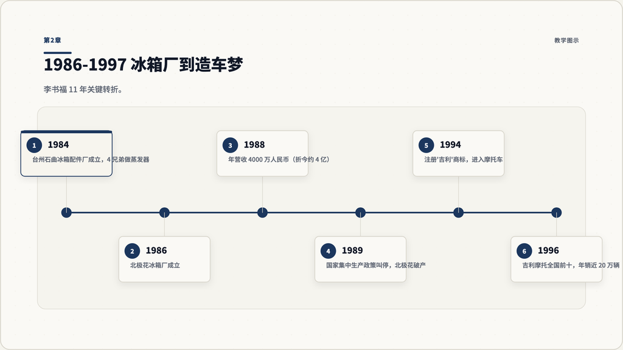

第2章：1986-1997 关键事件链

### 2.1 从冰箱配件开始

主营业务——**做冰箱的蒸发器**。

是的，他们的第一桶金不是来自卖整机，是来自给国营冰箱厂做**最不起眼的一个零件**——蒸发器。

[醒木]

到 1988 年——

**年销 4000 万人民币**——按当时的物价折算，**相当于今天 4 亿人民币的规模**。

### 2.2 1989 的第一次破产

可这事儿没能持续太久。

1989 年，国家发改委下文：**冰箱由国营企业集中生产，民营不得参与**。

[醒木]

一夜之间，**北极花冰箱厂被叫停**。李书福**第一次破产**。

诸位读者——这是一个**关键节点**——也是后来理解李书福”为什么这么爱买公司”的心理基础。

他在那一刻明白了一件事：**在中国搞制造业，光会做不够，还得有牌照、有资质、有政策**。**没牌照，做得再好，一夜归零**。

[关键认知]

这个教训李书福记了一辈子。后来他造汽车——**第一件事就是想办法搞牌照**。再后来收购沃尔沃、宝腾、路特斯——**核心动作还是搞牌照（市场进入资格、品牌资产、技术许可）**。

### 2.3 摩托车时代（1994-1997）

冰箱厂倒了之后，李书福先做了几年装修材料、皮革、摩托车配件——**到处试错**。

1994 年，机会来了。

那一年中国摩托车市场爆发，李书福**注册了”吉利”商标**——这是”吉利”两个字第一次出现在产品上——开始做摩托车。

吉利摩托车的策略简单直接——**便宜 + 模仿**。卖五千多块的款式，比合资品牌便宜三分之一。

到 1996 年——**吉利摩托车做到全国前十**。年销近 20 万辆，年利润 1 亿元人民币。

### 2.4 1997 — 那个让所有人嘲笑的决定

1997 年，李书福做了一个**所有人都觉得他疯了**的决定——

**用摩托车赚的钱去造汽车**。

[醒木]

他对身边人说了那句**被汽车圈儿当成笑话**的话——

**“汽车不就是四个轮子加两个沙发吗？”**

[醒木]

这句话在当时的语境下，**没有任何人当真**。

为什么？

因为 1997 年的中国汽车产业格局是——

- **乘用车牌照只发给国营和合资**。
- **整车开发周期五到八年**。
- **一条整车产线投资三十亿起步**。
- **没有合资外商支持，造车几乎不可能**。

李书福手里有什么？**一家年销 20 万辆摩托车的小厂**。

可他**真的就开始造车了**。

### 2.5 1997 年那张”买来的牌照”

要造车，第一件事——拿牌照。

李书福去找各大部门——**全部碰壁**。

后来他在四川德阳找到了一家**军工背景的小厂**——**四川德阳监狱汽车厂**——这家厂有”客车 + 越野车”的生产资质，但**早就名存实亡**。

李书福**收购了这家厂**——其实是**把它的牌照”买”过来**。

这是吉利第一次用并购解决问题——**用买的方式拿到了汽车牌照**。后来你会看到，吉利**几乎每一次重大动作**都是这个套路——**有问题，就买**。

### 2.6 这一章你要带走的三件事

- 李书福第一次破产（冰箱厂被政策叫停）让他刻骨铭心——**没牌照，做得再好都不算**。
- “**四个轮子加沙发**”这句话不是吹牛——是**对没有汽车工程背景的人的真实自我安慰**，也是把造车”去神秘化”的口号。
- 吉利造车的第一动作不是设计，不是研发——是**收购**。这个基因一直延续到 2010 年收购沃尔沃、2017 年收购路特斯。

### 2.7 把这段创业故事映射到你了解的行业

请挑一个你熟悉的传统行业（家电、家具、餐饮、零售），回答：

- 这个行业里有没有”李书福式的人”——从最不起眼的零部件起家、被政策叫停过、之后还能转型成功？
- 这种人后来的扩张模式，是不是也偏好”用买的方式解决问题”？
- 给你三百万人民币，你会不会跨界做汽车？为什么 1997 年的李书福敢做？

## 第3章 豪情下线与”四个轮子加沙发”（1998-2006）

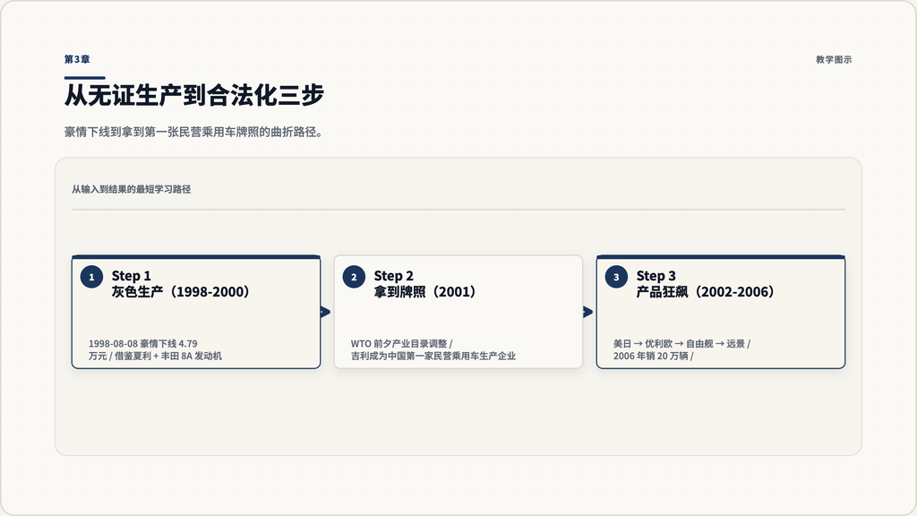

第3章：从无证生产到合法化三步

### 3.1 第一辆车豪情

1998 年 8 月 8 日——这日子值得记一下——

**第一辆吉利”豪情”轿车在浙江临海工厂下线**。

豪情这辆车长什么样？

**外观借鉴夏利**。**底盘借鉴夏利**。**发动机用的是夏利同款的丰田 8A**。售价——**4.79 万元人民币**。

[一个对照]

1998 年的合资紧凑型轿车售价多少？

- **大众桑塔纳**：13 万元。
- **大众捷达**：12 万元。
- **天津夏利**：6-7 万元。

**豪情比夏利还便宜两万**——这是中国当时”**民营造车第一次正面冲击合资和国营**”。

### 3.2 卖不出去的早期产品

可这事儿一开始**根本不顺**。

豪情第一年——**只卖了 100 多辆**。

为什么这么少？

因为吉利**根本没有乘用车销售牌照**——也就是说，**这车造出来不能合法上路**。

李书福只能**在浙江本地销售，加上一些灰色操作**——把车以”摩托车配件运输车”的名义注册——非常艰难。

[醒木]

1999 到 2001 年——吉利**面临的最大问题不是市场，是合规**。

2001 年——**关键一年**——

中国加入 WTO 之前，国家发改委做了一次产业目录调整——**民营资本可以申请乘用车生产资质了**。

李书福**冲到第一批**——**吉利成为中国第一家拿到民营乘用车生产许可证的企业**。

[醒木]

诸位，**这不是一张普通的纸**——

**这是中国汽车工业改革开放的一个标志**。

2001 年之前——**没有任何一家中国民营企业可以合法造乘用车**。 2001 年之后——**吉利可以了**。然后是奇瑞、长城、比亚迪……

### 3.3 2001-2006 的产品狂飙

拿到牌照之后，吉利车型像下饺子一样——

- **2002**：**美日** Meirui 上市。
- **2003**：**优利欧** Youliou 上市。
- **2005**：**自由舰** Ziyoujian 上市。
- **2006**：**远景** Yuanjing 上市。

这些车的共同特征——

- **价格便宜**（3-7 万元）。
- **外观模仿合资品牌**（自由舰像丰田 NCP10，远景像丰田卡罗拉）。
- **质量参差不齐**。
- **销量持续上涨**。

到 2006 年——**吉利全年销量突破 20 万辆**——**中国民营乘用车第一**。

### 3.4 这个时期被消费者记住的”烂”

可话说回来，**1.0 时代的吉利在质量上确实问题不小**。

那个年代的吉利车——

- **三大件耐久性差**：发动机噪音大、变速箱顿挫、底盘共振。
- **内饰塑料感重、做工粗糙**。
- **小毛病多**：异响、漏油、空调失灵。

老百姓口口相传一句话——

**“吉利车——三年小毛病、五年大毛病、十年废铁一堆。”**

[醒木]

诸位，这印象在中国消费者心里**扎了至少十年**。

到 2024 年——即便吉利的产品质量早就达到合资水平——**部分消费者仍然带着”老吉利”的滤镜在看新吉利**。

**这是早期”价格战 + 模仿 + 质量妥协”留下的长期心智负债**。

### 3.5 这一阶段做对的三件事

虽然质量饱受诟病，但 1998-2006 年吉利**做对了三件事**：

- **建立了完整的整车制造能力**——从冲压到焊接到涂装到总装。
- **建立了民营车企的渠道体系**——上千家经销商。
- **建立了”汽车也能像家电一样卖便宜”的市场认知**——把豪华汽车的”祛魅”做了一半。

这三件事是后来吉利能撑住转型代价、能完成沃尔沃收购的**基础设施**。

### 3.6 这一章你要带走的三件事

- 2001 年的乘用车牌照——**是中国汽车民营化的标志事件**——吉利是第一张。
- 1998-2006 年的”价格战 + 模仿”是有代价的——质量印象深入人心，**十年都消不掉**。
- 这一阶段建立的整车制造和渠道体系，是**后续故事的基础设施**。

### 3.7 给”低质量印象”算一笔账

请挑一个你熟悉的国产品牌（不一定是汽车，可以是家电、手机、化妆品），回答：

- 它早期有没有”低质量印象”？
- 这种印象在消费者心里**保持了多少年才消退**？
- 它后来用什么方式打掉这个印象？是出新品牌、还是收购海外品牌、还是技术升级？

把答案写下来。这是”**心智负债清算**”的练习。

## 第4章 宁波宣言（2007-2009）

[figure not shown]

第4章：1.0 时代 vs 2.0 时代对照

### 4.1 2007 那场”洗心革面”的发布会

2007 年 5 月，宁波。

吉利在自家工厂开了一场战略发布会，**标题朴素得不像营销动作**——

**“宁波宣言”**。

李书福亲自上台，说了一段话，**成为吉利历史的转折点**——

> **“造老百姓买得起的好车——已经不够了。 吉利要做老百姓买得起的—— 最安全、最环保、最节能的好车。”**

[醒木]

诸位，这段话**听起来朴素**。

可它的含义是什么？

**吉利公开宣布**——**放弃打价格战，转向价值战**。

[关键认知]

这就是后来在汽车圈儿被反复引用的——**“吉利 2.0 转型”**。

### 4.2 1.0 时代 vs 2.0 时代

把宣言前后对比一下：

| 维度 | 1.0 时代（1998-2006） | 2.0 时代（2007-2014） |
| --- | --- | --- |
| 核心策略 | 低价模仿 + 渠道下沉 | 技术升级 + 品牌再造 |
| 主力车型 | 豪情 / 美日 / 优利欧 / 自由舰 | 帝豪 EC7 / 全球鹰 / 英伦 SC7 |
| 价格定位 | 3-7 万元 | 7-12 万元 |
| 质量定位 | “够用就好” | 对标合资同级 |
| 品牌策略 | 单一吉利 | 三品牌矩阵（全球鹰 / 英伦 / 帝豪） |

[醒木]

注意——**2007 年宣布之后，吉利没有立刻翻盘**。

事实上，**2007-2010 年三年——吉利销量增长放缓、利润下滑**。

为什么？

因为”放弃低价”在当时——意味着**抛弃自己赖以生存的客户**。老吉利车主一看新吉利涨价了——**就不买了**。新客户呢？**还没建立起”吉利能做好车”的认知**——**也不买**。

这就是所有低端品牌升级时**最难的一段路**——**两头不靠岸**。

[醒木]

李书福扛住了。

### 4.3 帝豪 Emgrand：2.0 时代的旗舰

2009 年 8 月——**帝豪 EC7** 上市。这是**吉利 2.0 时代真正的代表作**。

帝豪做对的几件事——

- **完全新设计**：不再借鉴丰田卡罗拉，**自家造型团队主导**。
- **底盘升级**：搭载源自国际供应商的技术。
- **品控提升**：四大工艺全面升级。
- **价格上探**：起售价 **7.58 万元**——比老吉利贵 50%。

帝豪上市第一年——卖了 **5 万辆**。 第二年——**12 万辆**。 2014 年——**累计 100 万辆**——**自主品牌中级轿车第一**。

[醒木]

帝豪是吉利**第一辆真正能在合资品牌面前抬起头**的车。

它的意义不只是销量——是**心智的部分翻转**——老百姓开始觉得”**吉利也能造好车**”。

### 4.4 三品牌实验的失败

宁波宣言之后，吉利做了一个**事后看是错误的决定**——**三品牌战略**。

- **全球鹰 Global Hawk**——主打年轻人，对标本田 / 丰田。
- **英伦 Englon**——主打商务，定位”英伦优雅”。
- **帝豪 Emgrand**——主打中高端家用。

三个品牌——**三个销售网络、三个广告投放、三个产品线**。

结果呢？**全乱套**。

- 消费者分不清三个品牌的区别。
- 经销商内部互相抢客户。
- 营销费用激增、利润压低。

到 2013-2014 年——**吉利公开承认三品牌战略失败**。把全球鹰和英伦”**收回主品牌**”，只保留帝豪作为独立品牌。

[醒木]

诸位，**这段失败值得记住**。

它告诉你一件事——**品牌不是越多越好**。一家公司能不能同时运营多个品牌——**取决于产品差异性 + 资源充足度 + 渠道独立性**。当年吉利三个条件都不满足——所以三品牌实验**烧了几年钱才把账算清**。

### 4.5 2009 那个让世界震惊的暗线

可就在 2009 年——吉利公开搞品牌矩阵、公开宣布转型的同一年——

**李书福在悄悄做一件事**——

**他在和福特谈判，准备收购沃尔沃**。

[醒木]

这事儿当时在汽车圈儿**就是个笑话**。

可李书福**真的做成了**。

[醒木 · 重击]

且听**第五回**——**18 亿美元蛇吞象**。

### 4.6 这一章你要带走的三件事

- 2007 宁波宣言——**吉利从价格战转向价值战**——但代价是三年的销量增长放缓。
- 帝豪是 2.0 时代的旗舰——上市第一年 5 万辆、5 年累计 100 万辆——**心智部分翻转**。
- 三品牌实验失败——**品牌不是越多越好，要看产品 / 资源 / 渠道三条件**。

### 4.7 给你熟悉的品牌做一次转型评估

请挑一个正在做高端化转型的国产品牌（任何行业），回答：

- 它的”宁波宣言”是哪一天？或者还没发生？
- 它有没有过”三品牌实验失败”式的弯路？
- 它现在处在转型的哪个阶段——**两头不靠岸**？**心智部分翻转**？还是**完全成功**？

## 第5章 18 亿美元蛇吞象：2010 年的沃尔沃收购

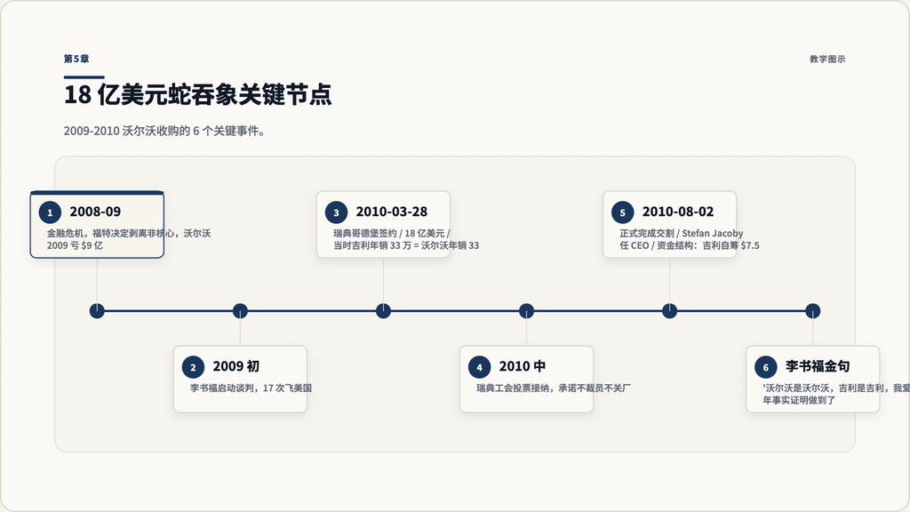

第5章：2009-2010 沃尔沃收购关键节点

### 5.1 一笔让全世界都没看懂的交易

2010 年 3 月 28 日，瑞典哥德堡。

**福特汽车**与**浙江吉利控股集团**签署协议——

**福特以 18 亿美元的价格——将瑞典豪华汽车品牌沃尔沃汽车（Volvo Cars）100% 的股权——出售给吉利**。

[醒木]

这是**中国汽车工业历史上**——**第一次**——**也是当时金额最大的一次**——**海外整车品牌全资收购**。

[关键数字]

- **签约日**：2010-03-28。
- **完成交割**：2010-08-02。
- **总价**：**18 亿美元**——其中 **2 亿美元票据 + 16 亿美元现金**。
- **吉利当时身份**：**中国第十大乘用车企业**。
- **沃尔沃当时身份**：**福特旗下亏损资产**——2009 年亏损 9 亿美元。

### 5.2 为什么福特要卖沃尔沃

要理解这场收购，先得理解福特为什么卖。

2008 年的金融危机——美国三大车企（福特、通用、克莱斯勒）**全部濒临破产**。

通用和克莱斯勒进了破产保护——福特靠**剥离非核心资产**才活下来。

福特陆续卖掉了——

- **2007**：阿斯顿马丁（Aston Martin）。
- **2008**：捷豹路虎（Jaguar Land Rover，卖给印度塔塔）。
- **2010**：**沃尔沃**（卖给吉利）。

福特要的是**专注美国本土的福特 + 林肯**——海外豪华品牌全部出清。

### 5.3 为什么吉利敢买

可吉利有什么资格买？

**2009 年吉利汽车的销量——33 万辆**。 **2009 年沃尔沃的销量——33 万辆**。

[醒木]

**两家公司销量一样大**——但是——

- **沃尔沃的研发预算**——**一年 20 亿美元**。
- **吉利的研发预算**——**一年 2 亿美元**。

吉利的**净利润 11 亿人民币**——折合 **1.7 亿美元**——**买沃尔沃要 18 亿**——**相当于吉利十年净利润**。

诸位，**这就是字面意义上的”蛇吞象”**。

### 5.4 钱从哪儿来

李书福这盘棋下得很妙——**18 亿美元里头，吉利自己只出了 41%**。

具体出资结构（按当时的公开信息）——

- **吉利集团自筹**：约 **7.5 亿美元**。
- **大庆国资 + 上海嘉定国资**：约 **6.5 亿美元**——为吉利在当地建沃尔沃工厂换股。
- **海外银团贷款 + 福特票据**：约 **4 亿美元**。

[醒木]

这一手——**用地方政府的钱解决了大头**。

地方政府图的是什么？**沃尔沃在当地建厂、带来 GDP 和就业**。

李书福图的是什么？**用别人的钱买自己心仪的资产**。

这是**典型的”杠杆并购”**——但 11 年后中国并购圈儿才开始普及的玩法——**李书福 2010 年就做了**。

### 5.5 福特的”嫁妆”

这场交易里头有一个**关键细节**——

**18 亿美元不只是买沃尔沃的股权——还包括沃尔沃的所有技术知识产权 + 9 个全球品牌权利 + 工厂 + 经销商网络**。

更妙的是——**福特签字承诺**——

- 在收购后**继续向沃尔沃供应零部件 5 年**。
- 不**追讨沃尔沃所用的福特平台技术**。

[醒木]

这意味着——

**吉利买到的不是一个空壳沃尔沃**——而是一个**完整的、有福特技术支持期、能立刻继续生产的沃尔沃**。

### 5.6 三个让人记住的细节

**细节一：李书福亲自上谈判桌**。

李书福不会英语——但他**亲自飞了 17 次美国**——和福特高层谈判。重要的时候用翻译——更多的时候**用诚意 + 耐心**。

福特方面后来公开说——**“李书福让我们相信他对沃尔沃的尊重是真的——这是我们卖给他的核心原因。”**

**细节二：那句”我爱你”**。

**“沃尔沃是沃尔沃，吉利是吉利——我爱你，但你是你。”**

[醒木]

这句话意思是——**收购之后我不会让吉利去管沃尔沃，沃尔沃保留独立运营**。

后来 14 年的事实证明——李书福**说到做到了**——这是后面沃尔沃复活的核心原因。

**细节三：瑞典工会的接纳**。

收购最关键的不是钱——是**瑞典工会的态度**。

瑞典工会一开始**坚决反对中国人接手**。李书福亲自去哥德堡——**用承诺打动工会**：

- **不裁员**。
- **不关瑞典工厂**。
- **保留瑞典管理团队**。
- **在中国增设工厂——不是替代瑞典——是补充**。

瑞典工会最终**投了赞成票**——这是收购能完成的关键。

### 5.8 用”沃尔沃收购”复盘一笔你了解的并购

请挑一个你了解的并购案（不一定是汽车，可以是科技、消费、金融），回答：

- 这笔并购的”福特嫁妆”是什么？（技术过渡期、专利、品牌、渠道）
- 这笔并购有没有”瑞典工会”？（关键利益方）
- 收购方有没有李书福那种**“我爱你但你是你”**的克制？还是上来就大刀阔斧改组？
- 最后效果如何？

## 第6章 沃尔沃复活与领克诞生（2010-2018）

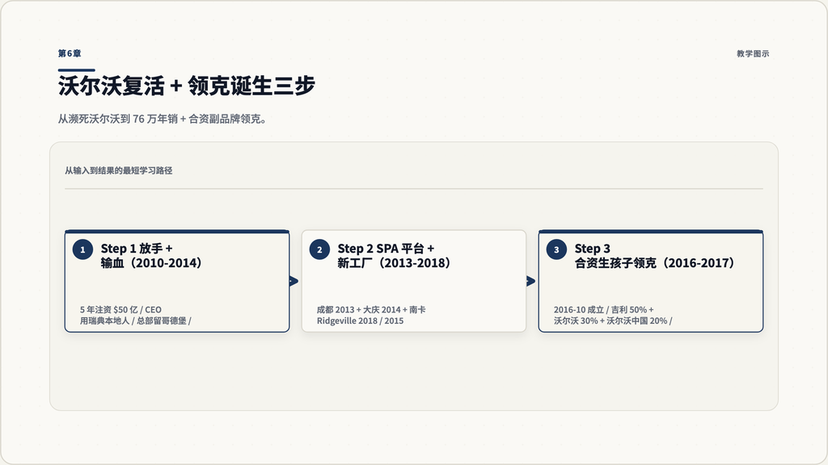

第6章：沃尔沃复活 + 领克合资三步

### 6.1 一个被低估的”放手”

收购后的**第一件让全世界震惊**的事情——李书福**真的没动沃尔沃**。

具体表现——

- **CEO 用瑞典本地人**——Stefan Jacoby 上任，后由 Håkan Samuelsson 接任。
- **总部留在哥德堡**——不搬到杭州。
- **设计中心保留在瑞典**——不带到中国。
- **品牌定位由瑞典管理层决定**——吉利不插手。

[醒木]

李书福只给沃尔沃**钱 + 中国市场入口**——**其他全部放手**。

这件事——**中国并购圈儿**——**从此被反复引用**。

### 6.2 钱在哪里——50 亿美元注资

收购之后 5 年里——**吉利向沃尔沃注资了约 50 亿美元**。

这笔钱用在哪——

- **新平台开发**：SPA 可扩展平台（Scalable Product Architecture）。
- **新工厂建设**：成都工厂（2013）+ 大庆工厂（2014）+ 美国南卡 Ridgeville 工厂（2018）。
- **品牌重塑**：从”安全工程师品牌”升级到”北欧豪华品牌”。

到 2015 年——**SPA 平台首款车型 XC90 上市**——**全球销量回到上升通道**。

到 2018 年——**沃尔沃全球销量 64.2 万辆**——**比收购时（33 万辆）翻了一倍**。

到 2024 年——**沃尔沃全球销量 76 万辆**——**且 23% 是纯电（EX30 / EX90）**。

[醒木]

诸位，这是中国并购史上**最经典的反向投资案例**——**收购方不是来榨干被收购方的，是真的来”养大”它的**。

### 6.3 中国市场的入口

吉利给沃尔沃带来了**中国市场**这把钥匙。

收购之前——**沃尔沃在中国年销 2 万辆**。 2018 年——**沃尔沃在中国年销 13 万辆**——**翻了 6 倍**。 2024 年——**约 15 万辆**——**中国是沃尔沃第二大市场**。

这部分增长**主要靠两件事**——

- **成都 + 大庆国产化**——降低关税和成本。
- **吉利的中国经销商网络**——快速铺开。

[关键认知]

**沃尔沃不是被吉利”管”成功的**——是被吉利**“输血 + 开门 + 放手”**成功的。

### 6.4 领克 Lynk & Co：2016 年的”合资生孩子”

2016 年 10 月——吉利和沃尔沃做了一件**全球汽车圈儿少见的事**——

**两家公司合资生了一个新品牌——领克 Lynk & Co**。

[醒木]

合资股权——**吉利 50% + 沃尔沃 30% + 沃尔沃中国 20%**——实际上吉利占主导。

领克的定位——

- **价格段**：15-30 万元。
- **目标用户**：年轻、城市、追求设计感的中产。
- **技术底子**：基于沃尔沃 CMA 平台（Compact Modular Architecture）。
- **设计风格**：瑞典 + 中国混合。

2017 年 11 月——**领克 01 上市**——起售价 15.88 万元。

第一年——**6 万辆**。 2019 年——**12 万辆**。 2024 年——**28.5 万辆**。

[醒木]

诸位，领克是**中国第一个真正意义上的”合资副品牌”——不是和外资 50:50 那种合资，是和”自己买来的外资”合资**。

这是一种**全球都没人玩过的玩法**。

### 6.5 领克全球化的挫折

领克 2017 年成立时就有**全球野心**——李书福亲自说”**领克要做面向全球的品牌**”。

2020 年——**领克在欧洲推出”订阅制”模式**——消费者**不买车，按月订阅**，每月 500 欧元含保险保养。

这个模式当时在欧洲**很有话题度**——但实际销量不大——欧洲消费者**还是更习惯买车**。

2022 年——**领克欧洲订阅模式调整为”销售 + 订阅并行”**——本质上**是承认订阅模式没做起来**。

到 2024 年——**领克欧洲年销约 2 万辆**——**远不及中国市场**。

[醒木]

这是**吉利全球化第一次重大挫折**——**用一个中国品牌打欧洲，比想象中难得多**。

后面会看到，**极氪在欧洲走了一条不同的路**——**不靠”中国品牌”叙事，而是用”沃尔沃血统”叙事**——**这是吉利的修正**。

### 6.6 这一章你要带走的三件事

- **沃尔沃复活的核心动作不是”管理”——是”放手 + 输血 + 开门”**。
- **领克是中国第一个”合资副品牌”——和自家收购的沃尔沃合资**——这是一种全球少见的玩法。
- **领克全球化的挫折让吉利明白**——用中国品牌叙事打欧洲市场——**难度极大**。

### 6.7 给你了解的并购做一次”放手测试”

请挑一个你了解的并购案，回答：

- 收购方有没有像李书福一样**完全放手**？还是上来就插手管理、换 CEO、合并总部？
- 五年后被收购方的销量变化如何？
- 如果改用”输血 + 开门 + 放手”的做法——结果会不会不一样？

## 第7章 购物狂人时代（2013-2018）

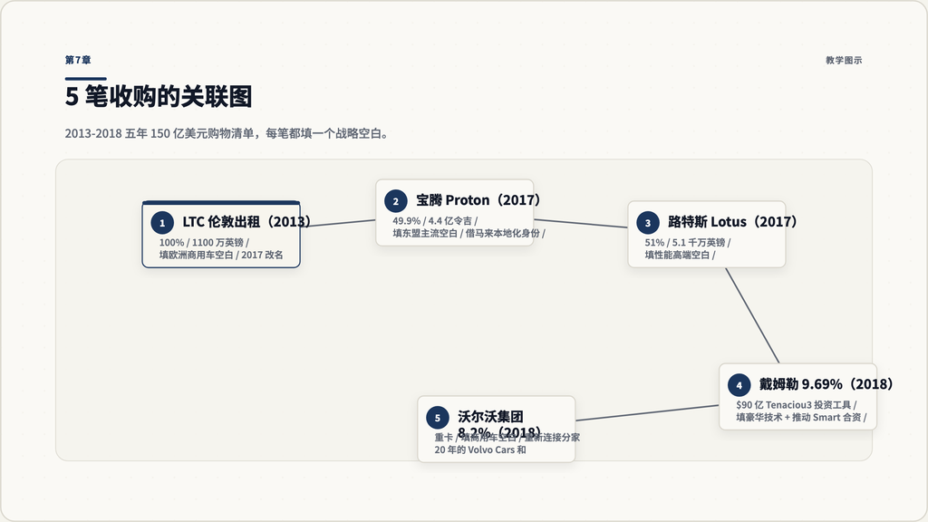

第7章：5 笔收购的关联图

### 7.1 沃尔沃只是开始

收购沃尔沃**没让李书福停手**——反而**让他停不下来**。

按时间顺序——

- **2013-02**：收购**伦敦出租车公司 LTC**（Manganese Bronze Holdings）的 100% 股权——约 1100 万英镑。
- **2017-06**：收购**马来西亚宝腾 Proton 49.9%**——约 4.4 亿令吉。
- **2017-06**：通过宝腾间接获得**英国跑车品牌路特斯 Lotus 51%**——约 5.1 千万英镑。
- **2018-02**：通过 Tenaciou3 投资工具收购**戴姆勒（Mercedes-Benz Group） 9.69%**——约 **90 亿美元**——成为戴姆勒最大单一股东。
- **2018-12**：收购**沃尔沃集团**（Volvo AB，重卡品牌）**8.2%**——成为最大单一股东。

[醒木]

诸位，**这五笔加在一起**——构成了一个让全世界汽车圈儿**膛目结舌**的**购物清单**。

### 7.2 每一笔背后的逻辑

不要把这五笔看成”乱买”——**每一笔都有自己的算盘**。

**伦敦出租车 LTC（2013）**：

- **真实价值**：伦敦黑色出租车的**百年品牌资产** + **TX 系列底盘技术** + **英国生产基地**。
- **吉利的算盘**：进入欧洲商用车市场 + 借伦敦市政府背书做新能源出租车。
- **2017 年改名 LEVC**（London Electric Vehicle Company）——开始生产 TX 增程版纯电出租车——**今天伦敦街头跑的黑色出租车——主流就是吉利产**。

**宝腾 Proton（2017）**：

- **真实价值**：马来西亚国民车企的**东盟市场牌照 + 产能**——宝腾拥有两座年产 20 万辆的马来工厂——**严重产能过剩**。
- **吉利的算盘**：进入东盟市场不需要从零起步——直接用宝腾的牌照 + 工厂 + 经销商网络。
- 2024 年——**宝腾在马来本土市场份额从 2017 年的 12% 提升到 22%**——**反弹明显**。

**路特斯 Lotus（2017）**：

- **真实价值**：英国超级跑车百年品牌——**当时濒临破产**——但**底盘工程 + 轻量化技术全球顶级**。
- **吉利的算盘**：定位为**集团的”性能 + 高端”心智锚**——配合极氪做电动跑车技术储备。
- 2022 年——**路特斯 Eletre 纯电 SUV 发布**——起售价 **10 万欧元**。2024 年路特斯**完成纳斯达克上市**。

**戴姆勒 9.69%（2018）**：

- **真实价值**：**全球豪华汽车的代表**——**梅赛德斯-奔驰** + **奔驰电动技术 EQ** + **车联网技术**。
- **吉利的算盘**：用**资本入股**的方式——**接触奔驰电动技术 + 推动 Smart 合资 + 长期资产配置**。
- 这笔投资到 2026 年——**吉利仍然持有 9.69%**——**没有减持**——**是吉利所有海外投资里最长期的一笔**。

**沃尔沃集团 8.2%（2018）**：

- **真实价值**：**全球第二大重卡品牌**——Volvo Trucks + Mack Trucks + Renault Trucks。
- **吉利的算盘**：**把”沃尔沃汽车”和”沃尔沃集团”这两个分家了 20 年的品牌——重新建立联系**——为吉利的商用车业务（Farizon 远程）借助沃尔沃集团技术 + 渠道。

[醒木]

诸位，**把这五笔放在一起看**——**每一笔都不是”为了买而买”**。

**每一笔都对应吉利集团战略地图上的一个空白格子**——

- 欧洲商用车 → LEVC。
- 东盟市场 → 宝腾。
- 性能高端 → 路特斯。
- 豪华技术 → 戴姆勒入股 + Smart 合资。
- 重卡 → 沃尔沃集团。

[关键认知]

**这就是”收购整合飞轮”的本质**——**不是无序扩张——是用并购精准填补战略空白**。

### 7.3 戴姆勒入股的两面

戴姆勒 9.69% 这笔**是争议最大的**。

**好的一面**——

- 2019 年——**吉利与奔驰成立 Smart 全球合资公司**——电动化重启 Smart 品牌。
- 2024 年——**戴姆勒 + 吉利联合开发的电动化平台技术**——开始反哺**领克 + 极氪**。

**不好的一面**——

- 2018 年入股时——**德国资本市场和媒体高度警惕**——担心**中国资本控制德国国宝企业**。
- 戴姆勒董事会**两度调整股权结构以限制单一股东影响**。
- 吉利**到 2024 年仍未进入戴姆勒董事会**——**90 亿美元只换来一个 9.69% 的财务投资人地位**——**未达预期**。

[醒木]

这笔投资**到 2026 年仍未盈利退出**——**是吉利所有重大投资里争议最持续的一笔**。

不过——2023 年 3 月——**吉利出售了 Daimler Truck（戴姆勒重卡，与 Mercedes-Benz Group 已经分拆）6.3% 股权——套现 €15 亿**——算是部分回收。

### 7.4 这一章你要带走的三件事

- **2013-2018 五年，吉利买了 5 家国际公司——总金额 150 亿美元+**。
- 每一笔**对应集团战略地图上的一个空白**——伦敦商用车 / 东盟 / 性能 / 豪华 / 重卡——**不是无序扩张**。
- 戴姆勒入股**到 2026 年仍是争议**——**资本影响力远低于股权比例**。

### 7.5 用”战略地图空白”反向评估你了解的公司

请挑一家正在做并购的中国公司（不一定是汽车），回答：

- 它的”战略地图”上有哪些空白格子？
- 它最近的几笔并购——是**精准填空**，还是**乱买**？
- 它有没有像戴姆勒入股那种**“投了钱但拿不到影响力”**的尴尬投资？

## 第8章 多品牌矩阵的形成（2018-2024）

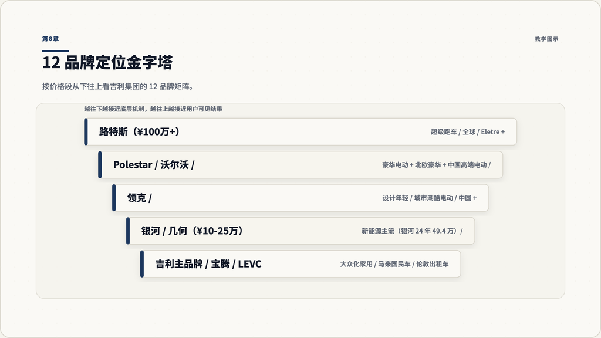

第8章：12 品牌定位金字塔

### 8.1 一张让人晕头转向的品牌列表

到 2024 年——吉利控股集团旗下的品牌——**多到让消费者晕头转向**——

**自有 + 合资**——

- **领克 Lynk & Co**：吉利 + 沃尔沃合资，15-30 万元（2016）。
- **极氪 Zeekr**：吉利全资高端电动品牌，30-80 万元（2021）。
- **Smart**：吉利 + 奔驰 50:50 合资（2019）。

**收购品牌**——

- **沃尔沃 Volvo Cars**：100% 持股，瑞典豪华，30-80 万元。
- **Polestar**：沃尔沃 + 吉利合资性能电动品牌（2017）。
- **路特斯 Lotus**：51% 持股，英国跑车，100 万+。
- **宝腾 Proton**：49.9% 持股，马来国民车。
- **LEVC**：100% 持股，伦敦出租车 + 商用车。

**自有商用 + 出行**——

- **Farizon 远程**：吉利全资商用车品牌（新能源货车）。
- **曹操出行**：吉利全资网约车平台。

[醒木]

把这些列出来——**集团旗下汽车相关业务超过 12 个独立品牌**。

### 8.2 怎么分工

这种品牌密度——**要想不撞车，必须有清晰分工**。

吉利的分工逻辑——**按”价格段 × 用户心智 × 地理市场”三轴切**——

| 品牌 | 价格段 | 心智 | 主战场 |
| --- | --- | --- | --- |
| Geely 主品牌 | 5-15 万 | 大众化家用 | 中国 + 新兴市场 |
| 银河 Galaxy | 10-25 万 | 新能源主流 | 中国 |
| 几何 Geometry | 6-15 万 | 经济型电动 | 中国（萎缩中） |
| 领克 Lynk & Co | 15-30 万 | 设计 + 年轻 | 中国 + 欧洲（艰难） |
| 极氪 Zeekr | 30-80 万 | 高端智能电动 | 中国 + 欧洲 + 中东 |
| Smart | 15-30 万 | 城市潮酷电动 | 全球 |
| 沃尔沃 Volvo | 30-80 万 | 北欧豪华 + 安全 | 全球 |
| Polestar | 40-100 万 | 性能电动 | 欧洲 + 美国 |
| 路特斯 Lotus | 100 万+ | 超级跑车 | 全球 |
| 宝腾 Proton | 5-15 万 | 马来国民车 | 东盟 |
| LEVC | 35-50 万 | 商用 + 出租车 | 英国 + 欧洲 |
| Farizon 远程 | 10-30 万 | 新能源货车 | 中国 + 拉美 + 东盟 |

[醒木]

诸位看官，**这张表本身就是一份咨询作品**——

**没有哪一家中国车企的品牌矩阵——比吉利更宽、更深、更国际**。

### 8.3 有些品牌”撞车”的事实

虽然分工清晰——**实际运营中仍然有撞车**。

**撞车二：沃尔沃 vs Polestar**——同一个生产基地（南卡 Ridgeville + 哥德堡），同样定位高端电动——市场区分模糊。

**撞车三：Smart vs 极氪**——都做城市电动，价格段交叠（20-30 万元欧元价）——欧洲市场互相争。

[醒木]

吉利**到 2026 年仍在调整品牌矩阵**——把 Geometry 几何**实质退场**（并入银河）——是修正的一部分。

### 8.4 这一章你要带走的三件事

- 吉利集团有**12 个独立汽车品牌**——**中国车企里最复杂的矩阵**。
- 品牌分工按”**价格段 × 心智 × 地理**”三轴切——但仍存在内部撞车。
- 这种复杂的矩阵**既是吉利的优势（覆盖全价格段、全人群、全地理）——也是吉利的成本（运营 + 营销 + 渠道 12 套体系）**。

### 8.5 给你熟悉的集团画品牌矩阵图

请挑一家你熟悉的多品牌集团（汽车 / 化妆品 / 家电 / 食品都行），回答：

- 它有多少独立品牌？
- 它的品牌分工按什么维度切？
- 有没有”内部撞车”的情况？
- 它的多品牌矩阵——是优势还是负担？

## 第9章 几何到极氪：纯电三步跳（2019-2024）

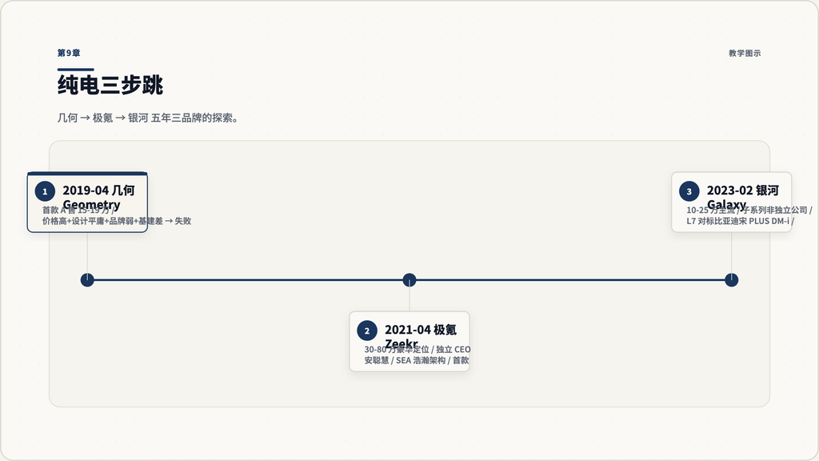

第9章：几何 → 极氪 → 银河 三步跳

### 9.1 第一步：几何 Geometry（2019）——失败的尝试

2019 年 4 月——吉利发布了**第一个独立电动品牌——几何 Geometry**。

定位——

首款车——**几何 A**——售价 15-19 万元——续航 410-500 公里。

**为什么失败？**

- **价格太高**——同期比亚迪秦 EV、广汽 Aion S 都比几何便宜。
- **设计平庸**——没有强烈记忆点。
- **品牌叙事弱**——消费者搞不清”几何”和”吉利”的区别。
- **充电基础设施差**——2019-2020 年纯电入门段市场还没起来。

到 2023 年——**几何品牌**销量持续低迷——**集团决定将几何并入银河系列**——**实质退场**。

[醒木]

诸位，**这是吉利电动化的第一次失败**——**教训非常贵**——也非常具体——**电动品牌不能只靠”独立”就成立——还要有清晰心智 + 价格优势 + 技术差异化**。

### 9.2 第二步：极氪 Zeekr（2021）——豪华路线

吸取几何的教训——2021 年 4 月——**吉利推出极氪 Zeekr**——**走完全相反的路线**：

- **高端定位**：30-80 万元。
- **强工程师文化**：直接对标特斯拉 Model S/X、保时捷 Taycan。
- **独立运营**：极氪有独立 CEO（安聪慧）、独立总部、独立融资。
- **基于 SEA 浩瀚架构**——吉利 + 沃尔沃联合开发的电动专用平台。

首款车——**极氪 001**——一辆**猎装跑车**——售价 28.9-38.6 万元——续航 500-700 公里——**外观设计极其抢眼**。

001 上市第一年——**6.4 万辆**——**远超预期**。

后续——

- **极氪 009**（2022）——豪华 MPV——56-79 万元——**对标埃尔法**。
- **极氪 X**（2023）——紧凑 SUV——20-30 万元。
- **极氪 007**（2024）——猎装轿车——21-29 万元。
- **极氪 7X**（2024）——中型 SUV——23-37 万元。

2024 全年——**极氪销 22.2 万辆**——**+87%**。

[醒木]

诸位，极氪是**吉利电动化第一个成功的品牌**。它做对了三件事——

- **不省钱**——豪华定位，让消费者愿意为设计 + 体验付溢价。
- **不打着吉利的旗号**——独立运营，避免”吉利 = 廉价”的心智污染。
- **借沃尔沃的技术血脉**——SEA 平台来自沃尔沃 / 极氪联合开发——天然有”北欧豪华”叙事。

### 9.3 第三步：银河 Galaxy（2023）——主流路线

2023 年 2 月——吉利做了第三次尝试——**银河系列**——**走主流路线**：

- **价格段**：10-25 万元——**这是中国新能源车销量最大的段**。
- **产品定位**：插混 + 纯电并行——**全面对标比亚迪 DM-i**。
- **设计风格**：年轻、科技、相对克制。
- **品牌策略**：作为 **Geely 主品牌内的子系列**——而不是独立公司——**降低运营成本**。

银河首批车型——**L7 SUV、L6 轿车、E5 SUV、E8 轿车**。

2024 全年——**银河销 49.4 万辆**——**+80%**——**成为吉利新能源销量主力**！

[醒木]

诸位，**银河三步跳的成功**——**完成了吉利电动化的最后拼图**——

- **几何**：失败的低端尝试。
- **极氪**：成功的高端独立品牌。
- **银河**：成功的中端主流品牌。

### 9.4 这一章你要带走的三件事

- **吉利电动化走了三步——失败一次，成功两次**——**几何失败的教训非常具体**。
- **极氪走豪华独立路线**——避开了”吉利 = 廉价”的心智污染。
- **银河走主流子系列路线**——直接对标比亚迪 DM-i 银河——**24 年销 49.4 万**。

### 9.5 给一个失败的子品牌做尸检

请挑一个你了解的”失败的子品牌”（不一定是汽车），回答：

- 它失败的原因是哪几个？价格、心智、渠道、还是技术？
- 母品牌从这次失败里学到了什么？
- 如果你是产品经理——你会怎么救它？

## 第10章 银河出世：吉利的新能源反击

[figure not shown]

第10章：银河 vs DM-i vs 智能新能源对照

### 10.1 2023 年那场”对标比亚迪”的发布会

2023 年 2 月 23 日——吉利在杭州亚运村开了一场战略发布会。

**主题**——“**吉利银河战略 - 新能源时代的中国主流答案**”。

李书福亲自上台——**说了一段火药味十足的话**——

> **“过去三年，新能源市场被比亚迪一家拿走了大半—— 不是因为它的产品多好—— 是因为传统车企转身慢。”**

> **“今天吉利要把银河打造成—— 新能源时代主流家用车的答案。”**

[醒木]

诸位，“**对标比亚迪**”——这四个字——**第一次被中国传统车企**——**公开放在 PPT 上**。

### 10.2 银河怎么对标 DM-i

银河首发车型——**银河 L7**——一辆中型插混 SUV——直接对标比亚迪宋 PLUS DM-i。

| 维度 | 比亚迪宋 PLUS DM-i | 吉利银河 L7 |
| --- | --- | --- |
| 价格 | 14.58-16.58 万 | 13.87-17.37 万 |
| 综合续航 | 1200 公里 | 1370 公里 |
| 亏电油耗 | 4.4L/100km | 4.4L/100km |
| 电池 | 比亚迪刀片 | 吉利神盾电池 |
| 智能 | DiLink 4.0 | 银河 NOS 系统 |

[醒木]

诸位，**几乎是一对一对标**——**价格不退让、参数不退让、智能不退让**——**就是要从比亚迪嘴里抢用户**。

### 10.3 神盾电池：吉利的”刀片”回应

银河战略的核心技术之一——**神盾电池**——是吉利对比亚迪刀片电池的**正面回应**。

神盾电池的关键特性——

- **磷酸铁锂化学**（和刀片一样安全）。
- **8 针刺穿不冒烟**（对标刀片的针刺试验）。
- **空间利用率 +20%**——通过电池包结构优化。
- **支持 10C 高倍率快充**——预留未来 1MW 闪充能力。

[醒木]

注意——**神盾电池在能量密度上仍略弱于宁德时代麒麟和比亚迪刀片**——但**对标比亚迪安全叙事**——**吉利成功在消费者心智里占了一格**。

### 10.4 银河的爆发速度

[醒木]

### 10.5 银河成功的真实原因

不要把银河成功归功于”产品力”或”价格力”——**真实原因是 4 件事的合力**：

- **极氪先打通了 SEA 平台 + 浩瀚电池工程**——银河可以**复用**——研发成本被极氪摊薄。
- **吉利主品牌的 5000+ 经销商网络**——银河天然有渠道——**不像新势力要从零建店**。
- **吉利的”老用户基础”**——很多 1.0 / 2.0 时代的吉利车主**到了换车周期**——**银河接住了这波换车需求**。
- **比亚迪 2024 年开始放慢**——给了银河抢用户的窗口。

### 10.6 这一章你要带走的三件事

- 银河是**吉利第一次”正面对标比亚迪”**——**敢用 PPT 写”比亚迪”三个字**。
- 神盾电池是对**刀片电池叙事的正面回应**——**安全叙事被吉利抢了一格**。
- 银河成功 = 极氪铺路 + 吉利老渠道 + 老用户换车窗口 + 比亚迪放慢——**不是单一原因**。

### 10.7 给一个”对标战”做战前评估

请挑一组你知道的”A 对标 B”的产品（不限行业），回答：

- A 在哪几个维度对标了 B？
- A 在哪几个维度**不对标 B**？这是有意的还是没做到？
- 一年后 A 抢到 B 多少份额？是不是抢到了它真正想要的用户？

## 第11章 Smart / Polestar / 领克：海外电动品牌的搏杀

[figure not shown]

第11章：三品牌海外表现对照

### 11.1 三个海外电动品牌

这三个品牌——**起点都很高**——**结果分化巨大**。

### 11.2 Smart：从”卖给中国人”到”卖回欧洲”

Smart 这个品牌——**戴姆勒做了 22 年**——**亏了 22 年**——**总亏损超过 60 亿欧元**。

2019 年 3 月——奔驰和吉利**各持 50%**——**成立 Smart 全球合资公司**——**电动重启**。

分工——

- **设计**：奔驰负责。
- **工程 + 制造**：吉利负责。
- **生产**：中国西安 Smart 工厂。
- **销售**：奔驰全球渠道 + 自营。

首款车——**Smart #1**——2022 年欧洲上市——一辆紧凑型纯电 SUV——**反响不错**。 后续——**Smart #3**（2023）、**Smart #5**（2024）。

2023 年——**Smart 全球销 7 万辆**。 2024 年——**Smart 全球销 9 万辆**——**仍未达到原计划 15 万的目标**。

[醒木]

Smart 在中国**没有打开市场**——主要卖到欧洲。在欧洲 **#1 占了 EVO 紧凑 SUV 段的一席**——但**远未到颠覆**。

### 11.3 Polestar：持续亏损的”明星”

Polestar 的故事更复杂。

2017 年——沃尔沃把 Polestar 从”性能调校部门”剥离出来——**和吉利合资成立独立品牌**——专注于**高性能电动**。

2022 年——**Polestar 通过 SPAC 在纳斯达克上市**——市值一度 **270 亿美元**。

但实际经营——

- 2024 Q1——**净亏 $3.23 亿**——交付 7,200 辆——**收入同比下滑 36%**。
- 2024 全年——**继续亏损扩大**。
- 2025 H1——**累计净亏破 $10 亿**！

[醒木]

Polestar 面临的真实问题——

- **产品定位混乱**：Polestar 1 是 PHEV 跑车、Polestar 2 是中型轿车、Polestar 3 是 SUV、Polestar 4 又是 SUV——**消费者搞不清品牌叙事**。
- **生产复杂**：Polestar 2 在中国生产，Polestar 3 已从中国转到沃尔沃**南卡 Ridgeville 工厂**——**应对美国对华关税**。
- **价格弱势**：Polestar 4 起售价 5.7 万美元——**和 Tesla Model Y、奔驰 EQE 直接竞争**——**没有明显优势**。
- **渠道分散**：欧洲 + 美国 + 中国都有店——**但每个市场份额都不大**。

2024 年——**沃尔沃将 €5 亿股权转给吉利**——**实质上是”沃尔沃不想再扛 Polestar 了”**——吉利接手主要持股。

[醒木 · 沉重]

诸位，**Polestar 是吉利集团目前最大的财务包袱**——**到 2026 年仍未盈利**——**且看不到清晰盈利时间表**。

### 11.4 领克：欧洲订阅模式的失败

第 6 章已经讲过——领克的欧洲”订阅模式”——**当时是个有话题度的实验**——**结果证明**——**欧洲消费者还是更习惯传统购买**。

2024 年——**领克欧洲销 2 万辆**——**远不及预期**。

修正策略——**关闭”独立品牌门店”——并入沃尔沃经销商网络共享**——本质上**承认领克在欧洲打不开**。

### 11.5 极氪：吉利海外电动的真正希望

相比 Smart / Polestar / 领克——**极氪走了一条不同的路**——

- **2024 年起进入欧洲**——**先选瑞典 / 荷兰**（沃尔沃 + 领克老渠道铺好的国家）。
- **不打”中国品牌”叙事**——**主打”瑞典哥德堡设计 + SEA 平台 + 极致性能”**。
- **价格段对标保时捷 Taycan 入门 + 特斯拉 Model S**——**避开主流红海**。
- **首款进入车型 001、X、7X**——产品力获得欧洲媒体认可。

2024-2026——**极氪扩展到 8 个欧洲市场**——**首批交付**。

但**销量仍小**——2024 极氪欧洲销量约 1 万辆——**距离规模化还远**。

### 11.7 给你了解的”明星品牌”做亏损评估

请挑一个你了解的”高估值但持续亏损”的明星品牌（任何行业），回答：

- 它的亏损来自哪几个原因？产品定位、生产、价格、渠道、还是营销？
- 它的盈利路径**清晰吗**？还是只在 PPT 上？
- 如果它的母公司决定”放弃”——你觉得能放下决心吗？

## 第12章 吉利的海外打法：借品牌出海

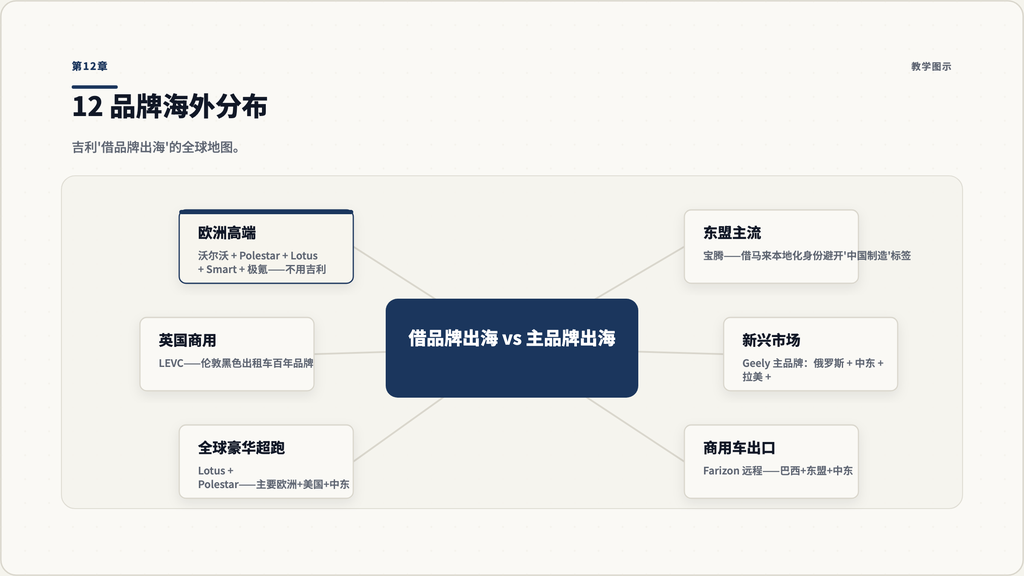

第12章：12 品牌海外分布

### 12.1 三种中国汽车出海打法

到 2026 年——中国车企的海外打法**清晰分化成三种**——

- **比亚迪式**：**主品牌全球统一**——BYD 一个 logo 打天下——自建海外工厂（泰国 / 巴西 / 匈牙利 / 土耳其）。
- **奇瑞式**：**海外副品牌优先 + 网格化建厂**——Omoda / Jaecoo 出海打头——10+ 海外工厂 + 100+ 国家。
- **吉利式**：**借品牌出海**——**用收购回来的国际品牌进入海外市场**——**Volvo + Lotus + Polestar + Smart + Proton + LEVC 各占一块**。

### 12.2 12 品牌的海外分布

把吉利集团的 12 个品牌按”主战海外”分类——

**全球品牌**——

- **沃尔沃 Volvo Cars**：全球 100+ 市场——年销 76 万辆。
- **Polestar**：欧洲 + 美国 + 中国——年销 4-5 万辆。
- **Smart**：欧洲为主 + 中国——年销 9 万辆。
- **路特斯 Lotus**：欧洲 + 美国 + 中东 + 中国 + 东南亚——年销 1-2 万辆。

**区域品牌**——

- **宝腾 Proton**：东盟（马来 + 印尼 + 泰国）——年销 15 万辆。
- **LEVC**：英国 + 欧洲（伦敦出租车）——年销 1-2 万辆。
- **领克 Lynk & Co**：中国主战 + 欧洲尝试。
- **极氪 Zeekr**：中国主战 + 欧洲 + 中东 + 东南亚——海外约 2 万辆。

**国内为主**——

- **吉利 Geely**：少量出口俄罗斯 + 中东 + 拉美 + 非洲——年销约 30 万辆海外。
- **银河 Galaxy**：基本国内为主。
- **几何 Geometry**：已实质退场。

**商用 + 出行**——

- **Farizon 远程**：商用车——海外进入巴西 + 东盟 + 中东。
- **曹操出行**：仅国内。

### 12.3 吉利海外打法的核心逻辑

诸位，**吉利的海外不是”吉利在出海”——是”吉利的旗下品牌在各自所在的市场上”**。

具体逻辑——

- **欧洲 - 高端段**：用沃尔沃 + Polestar + Lotus + Smart 打——**不用吉利 logo**。
- **东盟 - 主流段**：用宝腾打——**借马来本地化身份避开”中国制造”标签**。
- **英国 - 商用车**：用 LEVC 打——**借伦敦黑色出租车百年品牌**。
- **新兴市场（俄罗斯 / 中东 / 拉美 / 非洲）**：用 Geely 主品牌打——**因为这些市场对”中国制造”接受度高**。
- **欧洲高端电动**：用极氪打——**借沃尔沃 / 瑞典叙事**——**避开中国品牌偏见**。

[醒木]

这就是”**借品牌出海**”的本质——**不是用一个 logo 强行打天下——是让每个市场都有一个”对那个市场最舒服的脸”**。

### 12.4 这种打法的优势

- **避开”中国制造”心智偏见**——用本土品牌名进入。
- **降低渠道建设成本**——继承沃尔沃 / 宝腾 / LEVC / Smart 的现有经销商网络。
- **避开高关税壁垒**——本土生产可以用沃尔沃哥德堡 + Smart 中国 + 宝腾马来工厂——配合当地贸易协定。
- **品牌叙事天然**——百年豪华、马来国民车、英国出租车——**消费者天然有故事**。

### 12.5 这种打法的代价

- **运营成本高**——12 个品牌、12 套管理、12 套营销、12 套渠道——**总成本远高于单品牌出海**。
- **整合困难**——技术 + 平台 + 供应链 + 经销商如何统一管理——**至今没有完美答案**。
- **品牌之间撞车**——尤其在欧洲——沃尔沃 vs Polestar vs 极氪——**互相抢用户**。
- **资本回报慢**——Polestar 持续亏损、Smart 未达预期——**长期看是否值得仍存疑**。

### 12.6 这一章你要带走的三件事

- 中国汽车出海有**三种打法**——**比亚迪式（主品牌全球）、奇瑞式（副品牌网格）、吉利式（借品牌出海）**——**没有最优解，只有匹配禀赋**。
- 吉利”借品牌出海”的核心逻辑——**让每个市场有一个”对那个市场最舒服的脸”**。
- 这种打法的代价是**运营成本高 + 整合困难 + 品牌内部撞车**——**长期回报仍待验证**。

### 12.7 给一家公司选择出海打法

如果你是一家做消费电子的中国公司，准备进入欧洲市场，请回答：

- 你会选哪一种打法？比亚迪式、奇瑞式、还是吉利式？
- 如果你选吉利式——**你打算收购哪个欧洲百年品牌作为壳**？
- 你的预算够不够养”12 个品牌”那种复杂度？

## 第13章 横向对比：吉利 vs 比亚迪 vs 奇瑞 vs 上汽

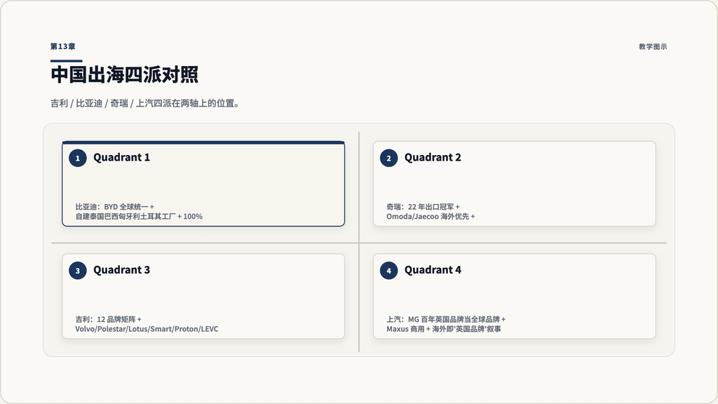

第13章：中国出海四派对照

### 13.1 中国汽车出海四派

到 2026 年——中国汽车出海格局基本定型——**四派代表四种武功**——

| 流派 | 代表 | 武功 |
| --- | --- | --- |
| **垂直一体化派** | 比亚迪 | 自研所有零件、主品牌全球统一、自建海外工厂 |
| **网格化副品牌派** | 奇瑞 | 出口冠军 22 年、Omoda / Jaecoo 出海优先、10+ 海外工厂 |
| **借品牌出海派** | 吉利 | 收购整合、12 品牌海外分布、借本土品牌避开”中国”心智 |
| **MG 借壳派** | 上汽 | 收购 MG 当全球品牌、海外即”英国百年品牌” |

| 维度 | 吉利（控股） | 比亚迪 | 奇瑞 | 上汽（含 MG） |
| --- | --- | --- | --- | --- |
| 2024 销量 | 333.7 万 | 427 万 | 260 万 | 401 万 |
| 起点 | 1986 冰箱配件 | 1995 手机电池 | 1997 芜湖国资 | 1950s 上海国资 |
| 创业类型 | 民营 | 民营 | 地方国资 | 中央国资 |
| 自有主品牌 | Geely + 银河 + 极氪 + 领克 | BYD + 王朝 + 海洋 + 三高端 | Chery + EXEED | 上汽乘用车（弱） |
| 收购品牌 | Volvo + Polestar + Lotus + Smart + Proton + LEVC | 无 | 无 | MG + Maxus |
| 海外副品牌 | （主要靠收购） | 无 | Omoda + Jaecoo | （主要靠 MG） |
| 海外工厂 | 沃尔沃哥德堡 + 成都 + 大庆 + 南卡 + 宝腾马来 + LEVC 英国 + Smart 西安 | 泰国 + 巴西 + 匈牙利 + 土耳其 + 乌兹别克 | 10+（俄 / 巴 / 印尼 / 埃及 / 西班牙 Ebro 等） | 泰国 + 印度 + 印尼 + 欧洲在选 |
| NEV 2024 占比 | 26% | 100% | 22% | 30% |
| 出海打法 | 借品牌出海 | 主品牌全球统一 | 副品牌网格化 | MG 当全球品牌 |
| 主要海外市场 | 欧洲 + 东盟 + 全球 | 东南亚 + 拉美 + 欧洲 | 俄 + 中东 + 南美 + 东盟 | 欧洲 + 东南亚 + 印度 |
| 2024 海外销量 | 控股集团约 130 万（含 Volvo / Polestar / Smart / Lotus） | 41.7 万 | 114 万 | MG 海外约 70 万 |

[醒木]

诸位，把这张表横着看——**四种武功各有所长，互不相同**。

### 13.3 学习者最容易看错的三件事

**第一**：**别用单一指标比较出海**。

如果只看”中国乘用车出口排名”——**奇瑞 22 年第一**。 如果看”集团海外销量绝对值”——**吉利第一**（含 Volvo 76 万）。 如果看”自有品牌海外销量”——**奇瑞第一**（114 万自有品牌纯出口）。

**三个指标三个冠军**——**看你怎么定义”出海”**。

**第二**：**吉利的海外销量大头来自被收购品牌**。

吉利控股 2024 海外销量约 130 万辆——其中——

- **沃尔沃 Volvo Cars**：海外约 60 万辆（除中国）。
- **Polestar**：约 4 万辆。
- **Smart**：约 8 万辆。
- **路特斯 Lotus**：约 1-2 万辆。
- **宝腾 Proton**：约 12 万辆（东盟）。
- **LEVC**：约 1-2 万辆。
- **吉利主品牌（包括俄罗斯等）**：约 30+ 万辆。

**如果剥离被收购品牌**——**吉利自有品牌的海外销量——只有 30-40 万辆**——**远不及奇瑞**。

这是个**心智上需要刻意区分**的数字。

**第三**：**没有最优解**。

**比亚迪式**赢的是**新能源浪潮 + 中国制造业升级**——但**重资产**。 **奇瑞式**赢的是**22 年新兴市场耕耘 + 副品牌灵活**——但**心智依然偏中国**。 **吉利式**赢的是**避开”中国”心智 + 借助百年品牌**——但**运营成本高 + 整合困难**。 **上汽式**赢的是**MG 百年品牌的全球辨识度**——但**自主创新弱**。

**判断哪种打法好——看你押的世界 5-10 年是怎么的**。

### 13.4 这一章你要带走的三件事

- 中国汽车出海**四派代表四种武功**——比亚迪 / 奇瑞 / 吉利 / 上汽——**互不相同**。
- 别用单一指标比较出海——**三个指标三个冠军**。
- 吉利的”海外销量”大头来自被收购品牌——**剥离 Volvo / Polestar / Smart 后吉利自有品牌海外销量只有 30-40 万辆**。

## 第14章 收购整合飞轮：吉利模式启示

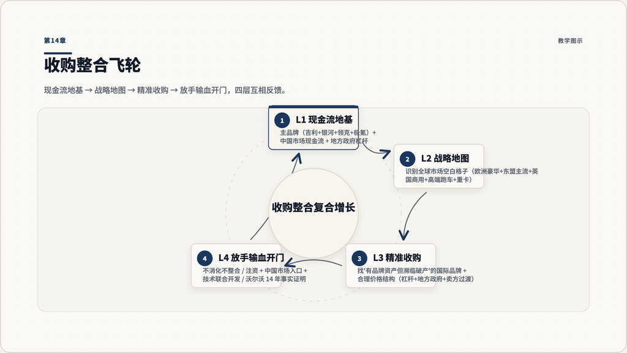

第14章：收购整合飞轮模型

### 14.1 把吉利 40 年抽象成一个模型

最后一章——把吉利所有故事压缩成一个**可迁移到其他公司的模型**——**收购整合飞轮**。

四层——

- **L1 — 现金流地基**：靠主品牌（吉利 + 银河 + 领克 + 极氪）创造**稳定的中国市场现金流**——为收购和长期整合提供燃料。
- **L2 — 战略地图**：识别**全球市场地图上的空白格子**——欧洲豪华 / 东盟主流 / 英国商用 / 高端跑车 / 重卡——**列出来**。
- **L3 — 精准收购**：找到那些**有品牌资产但濒临破产 / 被原 owner 边缘化**的国际品牌——用合理价格 + 合理结构（杠杆 + 地方政府 + 卖方过渡支持）收购。
- **L4 — “放手 + 输血 + 开门”整合**：不消化、不打乱、保持被收购方独立运营——**注资 + 中国市场入口 + 技术联合开发**。

四层互相反馈——

- **L1 提供资金给 L3**。
- **L3 扩张 L2 战略地图**。
- **L2 反向引导 L1 现金流投向**（哪个品牌该扶持哪个该放弃）。
- **L4 的成功（Volvo 案例）反过来增强 L1 的信心和能力**。

[醒木]

**当四层互相反馈——公司就进入了”收购整合复合增长”阶段**。

### 14.2 把这四层变成可执行 checklist

如果你管理一家正在做并购扩张的中国公司——

**L1：现金流地基**——

- 你的主营业务现金流稳定吗？
- 这个现金流能不能支撑 5 年 50 亿美元级别的并购？
- 你有没有”地方政府杠杆”可以借用？

**L2：战略地图**——

- 你画过”全球市场空白格子”地图吗？
- 你列出来要填的 5 个空白是哪 5 个？
- 你有清晰的填空顺序吗（先填哪个、后填哪个）？

**L3：精准收购**——

- 你找的标的——是**真正的好资产**但暂时困境，还是**真正的烂资产**？
- 你的价格 + 结构合理吗？还是在追价？
- 卖方愿不愿意给”过渡支持”（技术、专利、人员）？

**L4：放手 + 输血 + 开门**——

- 你收购后**能不能克制住”接管 + 整合”的冲动**？
- 你愿不愿意把中国市场作为”嫁妆”开放给被收购方？
- 你能不能容忍 5-10 年才看到回报？

### 14.3 这个模型不能复制的部分

诚实地说——吉利模式有一部分**不可复制**：

- **2008-2010 全球金融危机**——给了李书福**一辈子一次的低价收购窗口**（沃尔沃 18 亿 + LEVC 1100 万英镑）——今天没有这样的窗口。
- **2010 年的中美汽车市场结构**——给了吉利”中国市场反哺沃尔沃”的特殊红利——今天中国汽车市场内卷激烈——这个红利不复存在。
- **李书福这个人**——**敢借 25 万下海、敢花 11 年净利润买沃尔沃、敢 17 次亲飞美国谈判**——**这种企业家精神是不可复制的天赋**。

但**收购整合飞轮的结构本身可以复用**——它要求的不是天才——是**耐心、纪律和”放手让被收购方独立运营”的克制**。

### 14.4 收尾

吉利 1986-2026 这四十年——**从一家做冰箱蒸发器的小作坊**——到**一家拥有沃尔沃、路特斯、宝腾、Smart、Polestar、LEVC 的全球汽车集团**——**这是中国制造业全球化最完整的样本之一**。

它没有比亚迪那种”垂直一体化”的简洁。 它没有奇瑞那种”22 年出口冠军”的史诗。 它有的是——**一份长达 16 年的”购物清单”**——**和一份持续 14 年的”放手 + 输血”耐心**。

把这件事看清楚，对所有想做”**跨境并购整合**”的中国公司都是一面镜子：

**真正的护城河不是收购的胆量——是收购之后”放手”的克制**。

### 14.5 最后的练习

请用 500-800 字写一份”**收购整合飞轮自检报告**”——

- 你的公司（或你跟踪的公司）在哪一层最强？
- 哪一层最弱？
- 如果只能在一层投入更多资源——应该投哪一层？为什么？

写完之后保存好，6 个月后再看一次。

## 参考资料

以下是本教程依赖的公开资料（精选）：

- 沃尔沃官方收购完成公告：[Zhejiang Geely Completes Acquisition of Volvo Car Corporation](https://www.media.volvocars.com/global/en-gb/media/pressreleases/34397)
- 吉利控股 2024 销量公告：[2024 Sales by Geely Holding Brands Rise 22% to 3.337m Units, Targets 5m Units by 2027](https://zgh.com/media-center/news/2025-01-08/?lang=en)
- 吉利汽车（上市公司）2024 销量：[Geely Automobile 2024 Sales 2.17 Million Units, NEV +92%](https://www.bitauto.com/global/news/100197328486.html)
- 收购宝腾 + 路特斯：[Geely Acquires 49.9% of Malaysia’s Proton, Controlling Stake in Lotus](https://www.wardsauto.com/geely/geely-acquires-49-9-of-malaysia-s-proton-controlling-stake-in-lotus)
- 戴姆勒 9.69% 入股：[Chinese Tycoon Makes $9 Billion Bet on Mercedes E-Car Know-How](https://www.bloomberg.com/news/articles/2018-02-25/geely-plants-chinese-flag-in-heart-of-germany-with-daimler-stake)
- 出售 Daimler Truck 6.3%：[Chinese Billionaire Li Shufu Sells €1.5 Billion Daimler Truck Stake](https://www.bloomberg.com/news/articles/2023-03-16/chinese-billionaire-sells-1-5-billion-daimler-truck-stake)
- Smart 全球合资正式成立：[Mercedes-Benz and Geely Holding formally established global joint venture smart Automobile Co., Ltd.](https://media.smart.com/en-INT/260782-mercedes-benz-and-geely-holding-formally-established-global-joint-venture-smart-automobile-co-ltd-for-the-smart-brand/)
- Polestar 2024 财报：[Polestar Q1 2024 6-K Filing](https://www.sec.gov/Archives/edgar/data/0001884082/000119312524171427/d814222dex991.htm)
- Polestar 持续亏损：[Polestar Reports A Net Loss Of $1 Billion Through June 2025](https://carbuzz.com/polestar-billion-dollar-financial-losses-us-tariff-impact/)
- 极氪欧洲扩张：[Zeekr Begins Big Push into 6 European Countries](https://cleantechnica.com/2024/04/17/zeekr-begins-big-push-into-6-european-countries/amp)
- 吉利综合历史：[Wikipedia: Geely](https://en.wikipedia.org/wiki/Geely)
- 李书福背景：[Wikipedia: Li Shufu](https://en.wikipedia.org/wiki/Li_Shufu)
- 吉利完整画像：[Carnewschina: Big profile of Volvo’s owner Geely and its founder Li Shufu](https://carnewschina.com/2023/11/29/who-is-volvos-owner-geely-who-sells-china-made-evs-in-the-u-s/)

如果你想继续深入，可以从两个方向延伸：

1. **深度案例**：单独深读”沃尔沃 14 年复活全过程”、“戴姆勒入股 9.69% 与中德资本博弈”、“Polestar 的持续亏损与南卡产能转移”。
2. **比较学习**：把吉利的收购整合飞轮 与 大众集团（奥迪 / 保时捷 / 宾利 / 兰博基尼 / 杜卡迪 / 斯柯达 / 西雅特）做横向对比——**两家都是”多品牌矩阵”的典型，但起点和路径完全不同**。